# Doubly Robust Estimation of Causal Effects in Survival Analysis

Peirong Hao, Ravinder Singh, Kevin Ying, Adam Bress, Tom Greene, Yizhe Xu[^1]

2026-01-29

```r
knitr::opts_chunk$set(
  collapse = TRUE,
  comment = "#>",
  message = FALSE,
  warning = FALSE
)

set.seed(123456)
library(truncnorm)
library(survival)
library(pseudo)
library(adjustedCurves)
library(MASS)
library(knitr)
library(kableExtra)
library(dagitty)
library(parallel)
library(future.apply)
library(future)

n_cores <- detectCores() - 2
```

## Introduction

As noted in Funk et al. (2011), estimating causal effects of a treatment in observational studies is challenging due to confounding bias. Common approaches to controlling for confounding include *outcome regression* and *propensity score methods*.

- *Outcome regression methods* model the conditional expectation of the outcome given treatment and baseline covariates. Marginal outcome means for each treatment strategy are then obtained by setting treatment to “treated” or “control” for all subjects and averaging over the covariate distribution. The difference in these marginal means is a commonly used estimand for the average treatment effect (ATE).
- *Propensity score methods* first estimate the propensity score (PS), i.e., the probability of receiving treatment given covariates, and then apply inverse probability weighting to construct a pseudo-population in which treatment is independent of measured confounders.

Both approaches rely on correctly specified outcome or propensity score models, and misspecification of either can lead to biased estimates.

## Doubly Robust Estimation

Doubly robust (DR) estimation leverages both the **outcome regression model** and the **propensity score model**. Consider $n$ independent and identically distributed individuals indexed by $i$. Let $D$ denote a binary treatment (0 or 1), $Y$ the outcome of interest without censoring, and $\boldsymbol{Z} = (Z_1, Z_2, \ldots, Z_k)$ a set of baseline covariates. Let $\hat{e}(\boldsymbol{Z})$ be the estimated propensity score and $\hat{m}_d(\boldsymbol{Z})$ be the predicted outcome given $D$ and $\boldsymbol{Z}$. The DR estimator for the average treatment effect (ATE) is

$$\hat{\tau}_{DR} = \frac{1}{n} \sum_{i=1}^n
\left[
\frac{D_i Y_i}{\hat{e}(\boldsymbol{Z}_i)}
- \frac{(D_i - \hat{e}(\boldsymbol{Z}_i))}{\hat{e}(\boldsymbol{Z}_i)}
\hat{m}_1(\boldsymbol{Z}_i)
\right]
-
\left[
\frac{(1 - D_i) Y_i}{1 - \hat{e}(\boldsymbol{Z}_i)}
+ \frac{(D_i - \hat{e}(\boldsymbol{Z}_i))}{1 -
\hat{e}(\boldsymbol{Z}_i)} \hat{m}_0(\boldsymbol{Z}_i)
\right].$$

The DR estimator is also known as the **augmented inverse probability weighting (AIPW)** estimator. In this form, the second term in each bracket serves as the augmentation term that converges to zero when either the PS model or outcome models are correctly specified. The **doubly robustness** property ensures that the estimator remains unbiased as long as either the PS model or the outcome models are correctly specified. Intuitively, The DR estimator adds another layer of protection against model misspecification, which is crucial in observational studies. For detailed mathematical derivations, please refer to Funk et al. (2011).

If both PS and outcome models are correctly specified, the estimator is **semiparametric efficient** (Tsiatis 2006), meaning it attains the smallest possible variance among all regular, asymptotically unbiased estimators for the ATE. One caveat is that if either model is misspecified, the DR estimator for ATE remains unbiased, but the resulting estimator for variance is biased. In such cases, a bootstrap estimator of the asymptotic variance is recommended (Bai, Tsiatis, and O’Brien 2013).

The DR estimator requires standard identifiability assumptions in causal inference, including the stable unit treatment value assumption (SUTVA), positivity, consistency, and exchangeability.

For doubly robust estimators for continuous and binary outcomes, please refer to the [AIPW](https://cran.r-project.org/web/packages/AIPW/AIPW.pdf) R package from Zhong et al. (2021).

## Extension to Survival Analysis

Time-to-event outcomes are common in biomedical research and are often subject to right censoring due to loss to follow-up. In some situations, loss to follow-up occurs completely at random, known as *noninformative censoring*, which represents the simpler case. More often, the loss to follow-up depends on pre-baseline and post-baseline characteristics, referred to as *informative censoring*. For example, patients who are sicker at baseline or who develop treatment-related adverse events may be more likely to drop out early. In such situations, the censoring mechanism must be explicitly modeled as a function of baseline and time-dependent covariates. In this tutorial, we introduce a DR estimator for the simpler scenario with noninformative censoring under an observational study setting. We will discuss an alternative DR estimator for the informative censoring case in a future tutorial.

### Pseudo-observation-based DR estimator

We introduce additional notations to discuss right-censored outcomes. Let $T$ denote the survival time, $C$ the censoring time, and $S_d(t)$ the survival function under treatment $d$ at time $t$. We define the ATE as the difference in survival probabilities between treatment groups at time $t$, i.e., $S_1(t)-S_0(t)$.

Assuming loss to follow-up is completely at random, i.e., $C \perp T^{(d)}$, Wang (2018) proposed a DR estimator using pseudo observations. The first step is to construct pseudo-observations for the survival function at time $t$ using the Kaplan–Meier (KM) estimator:
$$\hat{S}_d^{i}(t) = n \hat{S}_d(t) - (n - 1)
\hat{S}^{-i}_{d}(t),$$
where $\hat{S}_d(t)$ is the KM estimate using all observations and $\hat{S}^{-i}_d(t)$ is the leave-one-out KM estimate with subject $i$ removed. The pseudo-values $\hat{S}_d^{i}(t)$ are (asymptotically) individual-level contributions such that $E[\hat{S}_d^{i}(t)|Z_i] \approx \hat{S}_d(t|Z_i)$.

Then, these pseudo-values replace the observed outcome $Y_i$ and act as censoring-adjusted outcomes under the assumption of random censoring. With $\hat{S}_d^{i}(t)$ treated as the outcome, a standard DR estimator is then applied using a PS model and an outcome regression model. The pseudo-observation-based DR estimator for ATE is:
$$\hat{\tau}^{pseudo}_{DR} = \frac{1}{n} \sum_{i=1}^n
\left[
\frac{D_i \hat{S}_d^i(t)}{\hat{e}(\boldsymbol{Z}_i)}
- \frac{(D_i - \hat{e}(\boldsymbol{Z}_i))}{\hat{e}(\boldsymbol{Z}_i)}
\hat{m}_1(t, \boldsymbol{Z}_i)
\right]
-
\left[
\frac{(1 - D_i) \hat{S}_d^i(t)}{1 - \hat{e}(\boldsymbol{Z}_i)}
+ \frac{(D_i - \hat{e}(\boldsymbol{Z}_i))}{1 -
\hat{e}(\boldsymbol{Z}_i)} \hat{m}_0(t, \boldsymbol{Z}_i)
\right],$$
where $\hat{m}_d(t, \boldsymbol{Z}_i)$ can be estimated using a Cox proportional hazards model and $\hat{e}(\boldsymbol{Z}_i))$ can be estimated using logistic regression. The variance of the resulting estimator can be obtained based on Equation (17) in Wang (2018).

## Implementation of the DR estimator

We now demonstrate how to implement the pseudo-observation-based DR estimator under the random censoring scenario.

### Data Generation

We first simulate the data according to the variable relationships depicted in the directed acyclic graph (DAG) below

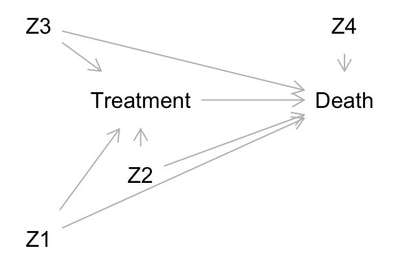

```r
dag <- dagitty("dag {
  Z1 -> Treatment
  Z2 -> Treatment
  Z3 -> Treatment
  Z1 -> Death
  Z2 -> Death
  Z3 -> Death
  Z4 -> Death
  Treatment -> Death
}")

coordinates(dag) <- list(x = c(Z1 = 0, Z2 = 0.5, Z3 = 0, Z4 = 1.5, Treatment = 0.5, Death = 1.5),
                         y = c(Z1 = 1, Z2 = 0.7, Z3 = 0, Z4 = 0, Treatment = 0.35, Death = 0.35))

plot(dag)
```

```r
alpha_0 <- -0.2
alpha_Z1 <- 0.6
alpha_Z2 <- 1.6
alpha_Z3 <- 1.6
alpha_Z1Z2 <- 0.8
alpha_Z2sq <- 0.5

beta_0 <- -2.6
beta_D <- -0.8
beta_Z1 <- 0.2
beta_Z2 <- 1.9
beta_Z3 <- 1.9
beta_Z4 <- 0.2
beta_Z2sq <- 0.8
beta_Z1Z3 <- 0.8

generate_data_noninf <- function(n = 500) {
  Z1 <- rnorm(n, 0, 1)
  Z2 <- rnorm(n, 0, 1)
  Z3 <- rnorm(n, 0, 1)
  Z4 <- rnorm(n, 0, 2)
  Z5 <- rnorm(n, 0, 2.5)
  Z6 <- rnorm(n, 0, 1)
  Z7 <- rnorm(n, 0, 1)
  Z8 <- rnorm(n, 0, 1)
  Z9 <- rnorm(n, 0, 1)

  logit_p <- (alpha_0 + alpha_Z1 * Z1 + alpha_Z2 * Z2 + alpha_Z3 * Z3 + alpha_Z1Z2 * (Z1 * Z2) + alpha_Z2sq * (Z2^2)) / 2.8
  p <- plogis(logit_p) # exp(logit_p) / (1 + exp(logit_p))
  D <- rbinom(n, 1, p) # Treatment indicator

  hazard <- exp(beta_0 + beta_D * D + beta_Z1 * Z1 + beta_Z2 * Z2 + beta_Z3 * Z3 + beta_Z4 * Z4 + beta_Z2sq * (Z2^2) + beta_Z1Z3 * (Z1 * Z3))
  T_event <- rexp(n, rate = hazard) # Event time from an exponential model
  #summary(T_event)

  T_censor <- rexp(n, rate = exp(-3)) # Censoring time based on random censoring
  #summary(T_censor)
  T_admin <- rep(5, n) # Administrative (random) censoring

  Time <- pmin(T_event, T_censor, T_admin) # Observed follow-up time
  Event <- as.numeric(T_event <= T_censor & T_event <= T_admin) # Event indicator

  return(data.frame(Z1 = Z1, Z2 = Z2, Z3 = Z3, Z4 = Z4, Z5 = Z5, Z6 = Z6, Z7 = Z7, Z8 = Z8, Z9 = Z9, D = D, Time = Time, Event = Event))
}
```

```r
data <- generate_data_noninf()

attr(data$Z1, "label") <- "Baseline value of Z1"
attr(data$Z2, "label") <- "Baseline value of Z2"
attr(data$Z3, "label") <- "Baseline value of Z3"
attr(data$Z4, "label") <- "Baseline value of Z4"
attr(data$Z5, "label") <- "Baseline value of Z5"
attr(data$Z6, "label") <- "Baseline value of Z6"
attr(data$Z7, "label") <- "Baseline value of Z7"
attr(data$Z8, "label") <- "Baseline value of Z8"
attr(data$Z9, "label") <- "Baseline value of Z9"
attr(data$D, "label") <- "Treatment indicator (1 = treated, 0 = control)"
attr(data$Time, "label") <- "Time index for longitudinal records"
attr(data$Event, "label") <- "Event indicator (1 = event occurred, 0 = otherwise)"

get_label <- function(x) {
  lbl <- attr(x, "label", exact = TRUE)
  if (is.null(lbl)) "" else as.character(lbl)
}

dict <- data.frame(
  Variable = names(data),
  Meaning  = vapply(data, get_label, character(1)),
  check.names = FALSE
)

knitr::kable(dict, caption = "Data Dictionary", row.names = FALSE)
```

Data Dictionary

| Variable | Meaning |
| --- | --- |
| Z1 | Baseline value of Z1 |
| Z2 | Baseline value of Z2 |
| Z3 | Baseline value of Z3 |
| Z4 | Baseline value of Z4 |
| Z5 | Baseline value of Z5 |
| Z6 | Baseline value of Z6 |
| Z7 | Baseline value of Z7 |
| Z8 | Baseline value of Z8 |
| Z9 | Baseline value of Z9 |
| D | Treatment indicator (1 = treated, 0 = control) |
| Time | Time index for longitudinal records |
| Event | Event indicator (1 = event occurred, 0 = otherwise) |

```r
summary(data$Time)
```

```
#>     Min.  1st Qu.   Median     Mean  3rd Qu.     Max.
#> 0.000053 0.668455 3.640693 2.968875 5.000000 5.000000
```

```r
table(data$Event)
```

```
#>
#>   0   1
#> 286 214
```

```r
censored_subjects <- data[data$Event == 0, ]
(early_dropout <- sum(censored_subjects$Time < 5))
```

```
#> [1] 74
```

```r
(admin_censored <- sum(censored_subjects$Time >= 5))
```

```
#> [1] 212
```

Among the 286 subjects with no events, 74 are early dropouts and 212 are administratively censored. Administrative censoring is random, so no additional modeling is needed. Early dropout could be covariate-dependent or occur completely at random, and we assume it is non-informative in this data generation.

```r
nrow(data[data$Event == 1 & data$Time <= 3, ])
```

```
#> [1] 190
```

With the simulation above, we can calculate the true survival probability.

```r
get_true_survival <- function(data, t, D) {
  hazard <- exp(beta_0 + beta_D * D + beta_Z1 * data$Z1 + beta_Z2 * data$Z2 + beta_Z3 * data$Z3 + beta_Z4 * data$Z4 +
            beta_Z2sq * (data$Z2^2) + beta_Z1Z3 * (data$Z1 * data$Z3))
  survival_probs <- exp(-hazard * t) # baseline hazard is constant under an expotential survival model
  return(mean(survival_probs))
}
```

We generate multiple datasets to compute the true ATEs at prespecified time points and corresponding 95% confidence intervals (CIs) using percentiles.

```r
n_datasets <- 100
datasets <- replicate(n_datasets, generate_data_noninf(), simplify = FALSE)

times <- c(1, 2, 3)
true_ate_samples <- matrix(NA, nrow = n_datasets, ncol = length(times))

for (i in 1:n_datasets) {
  # Compute potential survival probabilities by setting treatment to 1 and 0 for all individuals
  true_surv_1 <- sapply(times, function(t) get_true_survival(datasets[[i]], t, D = 1))
  true_surv_0 <- sapply(times, function(t) get_true_survival(datasets[[i]], t, D = 0))

  # Calculate ATE as difference in survival probabilities
  true_ate_samples[i, ] <- true_surv_1 - true_surv_0
}

true_ate_mean <- colMeans(true_ate_samples)
true_ate_ci_lower <- apply(true_ate_samples, 2, quantile, probs = 0.025)
true_ate_ci_upper <- apply(true_ate_samples, 2, quantile, probs = 0.975)

results_true <- list(ATE = true_ate_mean, ci_lower = true_ate_ci_lower, ci_upper = true_ate_ci_upper)

true_ate_with_ci <- sapply(1:length(times), function(i) {
  sprintf("%.3f (%.3f, %.3f)", results_true$ATE[i], results_true$ci_lower[i], results_true$ci_upper[i])
})
```

### Using R package

First, we implement the pseudo-observation-based DR estimator using the *adjustedsurv* function in the [adjustedCurves](https://cran.r-project.org/web/packages/adjustedCurves/adjustedCurves.pdf) R package.

```r
pseudo_dr_ate_pkg <- function(data, times, ps_correct = TRUE, or_correct = TRUE, use_bootstrap = TRUE) {

  data$D <- factor(data$D, levels = c(0, 1))

  # Propensity score model
  if (ps_correct) {
    ps_model <- glm(D ~ Z1 + Z2 + Z3 + I(Z2^2) + I(Z1*Z2), data = data, family = "binomial")
  } else {
    ps_model <- glm(D ~ I(Z5 * Z6) + I(Z7 * Z8) + Z9 + I(Z9^2), data = data, family = "binomial")
  }

  # Covariates used in the outcome model
  if (or_correct) {
    data$Z1_Z3 <- data$Z1 * data$Z3
    data$Z2sq <- data$Z2 * data$Z2
    or_covars <- c("Z1", "Z2", "Z3", "Z4", "Z1_Z3", "Z2sq")
  } else {
    or_covars <- c("Z5")
  }

  # Pseudo-observation-based DR estimator for survival probabilities
  # This method uses a generalized estimation equation for outcome model
  adj_surv <- adjustedsurv(
    data = data,
    variable = "D",
    ev_time = "Time",
    event = "Event",
    method = "aiptw_pseudo",
    treatment_model = ps_model,
    outcome_vars = or_covars,
    times = times,
    conf_int = TRUE,
    bootstrap = use_bootstrap,
    n_boot = 100, # In practice, set n_boot to a larger value (e.g., 1000).
    n_cores = if(use_bootstrap) n_cores else 1)

  # Treatment effect is defined as the difference in survival probabilities.
  ate_results <- adjusted_curve_diff(
    adj = adj_surv,
    group_1 = "1",  # Treated group
    group_2 = "0",  # Control group
    conf_int = TRUE,
    conf_level = 0.95)

  ate_at_times <- ate_results[ate_results$time %in% times, ]

  return(list(ATE = ate_at_times$diff, ci_lower = ate_at_times$ci_lower, ci_upper = ate_at_times$ci_upper))
}
```

We estimate the ATEs at prespecified time points and corresponding 95% CIs.

```r
results_package <- pseudo_dr_ate_pkg(data, times)

ate_with_ci <- sapply(1:length(times), function(i) {
  sprintf("%.3f (%.3f, %.3f)", results_package$ATE[i], results_package$ci_lower[i], results_package$ci_upper[i])
})

results_manual_tbl <- data.frame(
  ATE = c("Estimated", "True"),
  `T = 1` = c(ate_with_ci[1], true_ate_with_ci[1]),
  `T = 2` = c(ate_with_ci[2], true_ate_with_ci[2]),
  `T = 3` = c(ate_with_ci[3], true_ate_with_ci[3]),
  check.names = FALSE)

kable(results_manual_tbl, caption = "ATE (95% CI)", align = c('c', 'c', 'c', 'c')) %>%
  kable_styling(full_width = FALSE, font_size = 12)
```

ATE (95% CI)

| ATE | T = 1 | T = 2 | T = 3 |
| --- | --- | --- | --- |
| Estimated | 0.127 (0.060, 0.194) | 0.047 (-0.026, 0.120) | 0.069 (-0.006, 0.145) |
| True | 0.074 (0.068, 0.082) | 0.087 (0.079, 0.094) | 0.094 (0.085, 0.102) |

### Manual coding

The pseudo-observation-based DR estimator can be implemented manually

- We use a Cox regression for the outcome model rather than GEE as in the package above

```r
pseudo_dr_ate_manual <- function(data, times, ps_correct = TRUE, or_correct = TRUE) {

  # Outcome regression (Cox proportional hazard model)
  if (or_correct) {
    or_model <- coxph(Surv(Time, Event) ~ D + Z1 + Z2 + Z3 + Z4 + I(Z2^2) + I(Z1 * Z3), data = data)
  } else {
    or_model <- coxph(Surv(Time, Event) ~ Z5, data = data)
  }

  data1 <- data
  data1$D <- 1

  data0 <- data
  data0$D <- 0

  # Extract the linear predictors (Beta^T * Z) from fitted Cox models
  lp_1 <- predict(or_model, newdata = data1, type = "lp")
  lp_0 <- predict(or_model, newdata = data0, type = "lp")

  # Baseline survival functions
  bh <- basehaz(or_model, centered = FALSE)
  bh$surv <- exp(-bh$hazard)

  # Baseline survival probabilities at different times
  s0_f <- stepfun(bh$time, c(1, bh$surv))
  s0_t <- s0_f(times)

  # Predicted survival probabilities
  m1 <- sapply(s0_t, function(s0) s0 ^ exp(lp_1))
  m0 <- sapply(s0_t, function(s0) s0 ^ exp(lp_0))

  # Propensity scores
  if (ps_correct) {
    ps_model <- glm(D ~ Z1 + Z2 + Z3 + I(Z2^2) + I(Z1*Z2), data = data, family = "binomial")
  } else {
    ps_model <- glm(D ~ I(Z5 * Z6) + I(Z7 * Z8) + Z9 + I(Z9^2), data = data, family = "binomial")
  }
  e <- predict(ps_model, type = "response")

  # Pseudo-observations (individual estimates of the survival function at specified time points)
  pseudo_obs <- pseudosurv(time = data$Time, event = data$Event, tmax = times)$pseudo

  surv_1 <- numeric(length(times))
  surv_0 <- numeric(length(times))
  ATE <- numeric(length(times))

  for(j in 1:length(times)) {
    # DR for treated group
    term1_treated <- data$D * pseudo_obs[, j] / e
    term2_treated <- (data$D - e) * m1[, j] / e
    term_full_treated <- term1_treated - term2_treated
    surv_1[j] <- mean(term_full_treated)

    # DR for control group
    term1_control <- (1 - data$D) * pseudo_obs[, j] / (1 - e)
    term2_control <- (data$D - e) * m0[, j] / (1 - e)
    term_full_control <- term1_control + term2_control
    surv_0[j] <- mean(term_full_control)

    ATE[j] <- surv_1[j] - surv_0[j]
  }
  return(list(ATE = ATE))
}
```

We calculate the standard error (SE) of the ATE using bootstrapping

```r
se_bootstrap <- function(data, times, num_boot = 100) {
  # In practice, set n_boot to a larger value (e.g., 1000).
  n <- nrow(data)
  boot_results <- matrix(NA, nrow = num_boot, ncol = length(times))

  for (b in 1:num_boot) {
    boot_indices <- sample(1:n, size = n, replace = TRUE)
    boot_data <- data[boot_indices, ]
    boot_results[b, ] <- pseudo_dr_ate_manual(data = boot_data, times = times)$ATE
  }

  se <- apply(boot_results, 2, sd, na.rm = TRUE)
  return(list(se = se))
}
```

We calculate the 95% CI of the ATE using parametric bootstrapping assuming ATE is normally distributed

```r
results_manual <- pseudo_dr_ate_manual(data, times)
se_manual <- se_bootstrap(data, times)

# Calculate 95% confidence intervals
results_manual$ci_lower <- results_manual$ATE - 1.96 * se_manual$se
results_manual$ci_upper <- results_manual$ATE + 1.96 * se_manual$se

ate_with_ci <- sapply(1:length(times), function(i) {
  sprintf("%.3f (%.3f, %.3f)", results_manual$ATE[i],
  results_manual$ci_lower[i], results_manual$ci_upper[i])})

results_manual_tbl <- data.frame(
  ATE = c("Estimated", "True"),
  `T = 1` = c(ate_with_ci[1], true_ate_with_ci[1]),
  `T = 2` = c(ate_with_ci[2], true_ate_with_ci[2]),
  `T = 3` = c(ate_with_ci[3], true_ate_with_ci[3]),
  check.names = FALSE)

kable(results_manual_tbl, caption = "ATE (95% CI)", align = c('c', 'c', 'c', 'c')) %>%
  kable_styling(full_width = FALSE, font_size = 12)
```

ATE (95% CI)

| ATE | T = 1 | T = 2 | T = 3 |
| --- | --- | --- | --- |
| Estimated | 0.116 (0.053, 0.178) | 0.050 (-0.016, 0.116) | 0.079 (0.016, 0.142) |
| True | 0.074 (0.068, 0.082) | 0.087 (0.079, 0.094) | 0.094 (0.085, 0.102) |

### Crude estimation

Fit a crude Cox model with no covariate or propensity score adjustment to show the amount of confounding bias in our data

```r
crude_cox_estimator <- function(data, times) {

  crude_cox <- coxph(Surv(Time, Event) ~ D, data = data)
  treatment_effect <- coef(crude_cox)["D"]

  base_surv <- survfit(crude_cox)
  s0 <- summary(base_surv, times = times, extend = TRUE)$surv

  # Survival for treated group: S_baseline^exp(beta_D)
  surv_1 <- s0^exp(treatment_effect)

  # Survival for control group: S_baseline^exp(0)
  surv_0 <- s0

  ATE <- surv_1 - surv_0

  return(list(ATE = ATE))
}

results_crude <- crude_cox_estimator(data, times)
```

### Evaluate the performance of pseudo-observation-based DR estimator

We use the datasets generated previously to calculate RMSE, bias, and variance.

```r
plan(multisession, workers = n_cores)

calculate_metrics <- function(datasets, true_ate_samples, times, method = "package", ps_correct = TRUE, or_correct = TRUE) {

  n_datasets <- length(datasets)

  ate <- future_lapply(1:n_datasets, function(i) {
    library(survival)
    library(pseudo)
    library(adjustedCurves)

    est_results <- switch(
      method,
      "package" = pseudo_dr_ate_pkg(datasets[[i]], times, ps_correct = ps_correct, or_correct = or_correct,
                                    use_bootstrap = FALSE),
      "manual" = pseudo_dr_ate_manual(datasets[[i]], times, ps_correct = ps_correct, or_correct = or_correct),
      "crude" = crude_cox_estimator(datasets[[i]], times))

    est_results$ATE}, future.seed = TRUE)

  ate_all <- do.call(rbind, ate)

  bias <- colMeans(ate_all - true_ate_samples)
  variance <- apply(ate_all, 2, var)
  rmse <- sqrt(colMeans((ate_all - true_ate_samples)^2))

  return(list(bias = bias, variance = variance, rmse = rmse))
}
```

### Model misspecification scenarios

To illustrate the robustness of the DR estimator to model misspecification, we compare 4 scenarios:

- Scenario 1: Both the outcome model and the propensity score model are correctly specified.
- Scenario 2: The propensity score model is correctly specified, but the outcome model is misspecified.
- Scenario 3: The outcome model is correctly specified, while the propensity score model is misspecified.
- Scenario 4: Both models are misspecified.

```r
metrics_1_package <- calculate_metrics(datasets, true_ate_samples, times, method = "package",
                                       ps_correct = TRUE, or_correct = TRUE)
metrics_2_package <- calculate_metrics(datasets, true_ate_samples, times, method = "package",
                                       ps_correct = TRUE, or_correct = FALSE)
metrics_3_package <- calculate_metrics(datasets, true_ate_samples, times, method = "package",
                                       ps_correct = FALSE, or_correct = TRUE)
metrics_4_package <- calculate_metrics(datasets, true_ate_samples, times, method = "package",
                                       ps_correct = FALSE, or_correct = FALSE)

metrics_1_manual <- calculate_metrics(datasets, true_ate_samples, times, method = "manual",
                                      ps_correct = TRUE, or_correct = TRUE)
metrics_2_manual <- calculate_metrics(datasets, true_ate_samples, times, method = "manual",
                                      ps_correct = TRUE, or_correct = FALSE)
metrics_3_manual <- calculate_metrics(datasets, true_ate_samples, times, method = "manual",
                                      ps_correct = FALSE, or_correct = TRUE)
metrics_4_manual <- calculate_metrics(datasets, true_ate_samples, times, method = "manual",
                                      ps_correct = FALSE, or_correct = FALSE)

metrics_crude <- calculate_metrics(datasets, true_ate_samples, times, method = "crude")
```

```r
scenarios <- c(
  "0: Crude Cox (Unadjusted)",
  "1: Both Correct",
  "2: PS Correct, OR Incorrect",
  "3: PS Incorrect, OR Correct",
  "4: Both Incorrect")

# Combine values across all time points into a single string
format_values <- function(vec) {
  paste(sprintf("%.4f", vec), collapse = ", ")
}

# RMSE table
rmse_package <- c("—", format_values(metrics_1_package$rmse), format_values(metrics_2_package$rmse),
                  format_values(metrics_3_package$rmse), format_values(metrics_4_package$rmse))

rmse_manual <- c(format_values(metrics_crude$rmse), format_values(metrics_1_manual$rmse),
                 format_values(metrics_2_manual$rmse), format_values(metrics_3_manual$rmse),
                 format_values(metrics_4_manual$rmse))

rmse_table <- data.frame(Scenario = scenarios, Package = rmse_package, Manual = rmse_manual)

kable(rmse_table,
      col.names = c("Scenario", "T = 1, 2, 3", "T = 1, 2, 3"),
      caption = "Performance of the estimator (RMSE)",
      align = c('c', 'c', 'c')) %>%
  kable_styling(full_width = FALSE, font_size = 12) %>%
  add_header_above(c(" " = 1, "Package" = 1, "Manual" = 1))
```

Performance of the estimator (RMSE)

| Scenario | Package T = 1, 2, 3 | Manual T = 1, 2, 3 |
| --- | --- | --- |
| 0: Crude Cox (Unadjusted) | — | 0.1883, 0.2243, 0.2450 |
| 1: Both Correct | 0.0247, 0.0270, 0.0266 | 0.0257, 0.0277, 0.0287 |
| 2: PS Correct, OR Incorrect | 0.0376, 0.0346, 0.0346 | 0.0364, 0.0337, 0.0337 |
| 3: PS Incorrect, OR Correct | 0.0253, 0.0268, 0.0272 | 0.0367, 0.0330, 0.0324 |
| 4: Both Incorrect | 0.2178, 0.2348, 0.2431 | 0.2176, 0.2346, 0.2429 |

```r
# Bias table
bias_package <- c("—", format_values(metrics_1_package$bias), format_values(metrics_2_package$bias),
                  format_values(metrics_3_package$bias), format_values(metrics_4_package$bias))

bias_manual <- c(format_values(metrics_crude$bias), format_values(metrics_1_manual$bias),
                 format_values(metrics_2_manual$bias), format_values(metrics_3_manual$bias),
                 format_values(metrics_4_manual$bias))

bias_table <- data.frame(Scenario = scenarios, Package = bias_package, Manual = bias_manual)

kable(bias_table,
      col.names = c("Scenario", "T = 1, 2, 3", "T = 1, 2, 3"),
      caption = "Performance of the estimator (Bias)",
      align = c('c', 'c', 'c')) %>%
  kable_styling(full_width = FALSE, font_size = 12) %>%
  add_header_above(c(" " = 1, "Package" = 1, "Manual" = 1))
```

Performance of the estimator (Bias)

| Scenario | Package T = 1, 2, 3 | Manual T = 1, 2, 3 |
| --- | --- | --- |
| 0: Crude Cox (Unadjusted) | — | -0.1854, -0.2210, -0.2415 |
| 1: Both Correct | 0.0011, 0.0035, 0.0027 | 0.0014, 0.0038, 0.0029 |
| 2: PS Correct, OR Incorrect | -0.0001, 0.0026, 0.0020 | 0.0001, 0.0027, 0.0021 |
| 3: PS Incorrect, OR Correct | 0.0010, 0.0034, 0.0026 | -0.0247, -0.0176, -0.0136 |
| 4: Both Incorrect | -0.2141, -0.2309, -0.2391 | -0.2138, -0.2306, -0.2389 |

```r
# Variance table
var_package <- c("—", format_values(metrics_1_package$variance), format_values(metrics_2_package$variance),
                 format_values(metrics_3_package$variance), format_values(metrics_4_package$variance))

var_manual <- c(format_values(metrics_crude$variance), format_values(metrics_1_manual$variance),
                format_values(metrics_2_manual$variance), format_values(metrics_3_manual$variance),
                format_values(metrics_4_manual$variance))

var_table <- data.frame(Scenario = scenarios, Package = var_package, Manual = var_manual)

kable(var_table,
      col.names = c("Scenario", "T = 1, 2, 3", "T = 1, 2, 3"),
      caption = "Performance of the estimator (Variance)",
      align = c('c', 'c', 'c')) %>%
  kable_styling(full_width = FALSE, font_size = 12) %>%
  add_header_above(c(" " = 1, "Package" = 1, "Manual" = 1))
```

Performance of the estimator (Variance)

| Scenario | Package T = 1, 2, 3 | Manual T = 1, 2, 3 |
| --- | --- | --- |
| 0: Crude Cox (Unadjusted) | — | 0.0011, 0.0014, 0.0018 |
| 1: Both Correct | 0.0006, 0.0008, 0.0007 | 0.0007, 0.0008, 0.0008 |
| 2: PS Correct, OR Incorrect | 0.0014, 0.0012, 0.0012 | 0.0014, 0.0012, 0.0011 |
| 3: PS Incorrect, OR Correct | 0.0007, 0.0008, 0.0008 | 0.0007, 0.0008, 0.0009 |
| 4: Both Incorrect | 0.0016, 0.0019, 0.0020 | 0.0016, 0.0019, 0.0020 |

## Funding

This work was supported by Utah Clinical & Translational Science Institute (CTSI) Translational Innovation Pilot (TIP) Program Award (NCATS UM1TR004409).

## References

Bai, Xiaofei, Anastasios A. Tsiatis, and Sean M. O’Brien. 2013. “Doubly-Robust Estimators of Treatment-Specific Survival Distributions in Observational Studies with Stratified Sampling.” *Biometrics* 69 (December): 830–39. https://doi.org/10.1111/biom.12076.

Funk, Michele Jonsson, Daniel Westreich, Chris Wiesen, Til Stürmer, M. Alan Brookhart, and Marie Davidian. 2011. “Doubly Robust Estimation of Causal Effects.” *American Journal of Epidemiology* 173 (7): 761–67.

Tsiatis, Anastasios A. 2006. *Semiparametric Theory and Missing Data*. Springer Series in Statistics. New York, NY: Springer. https://doi.org/10.1007/0-387-37345-4.

Wang, Jixian. 2018. “A Simple, Doubly Robust, Efficient Estimator for Survival Functions Using Pseudo Observations.” *Pharmaceutical Statistics* 17 (1): 38–48.

Zhong, Yongqi, Edward H Kennedy, Lisa M Bodnar, and Ashley I Naimi. 2021. “AIPW: An r Package for Augmented Inverse Probability Weighted Estimation of Average Causal Effects.” *American Journal of Epidemiology*, July. https://doi.org/10.1093/aje/kwab207.

[^1]: Corresponding author: yizhe.xu@hsc.utah.edu